# Homework 1

Lai Wei

2024-07-01

## T1

```r
iowa.df<-read.csv("../data/iowa.csv",sep=';',header=T)
iowa.df
```

```
##    Year Rain0 Temp1 Rain1 Temp2 Rain2 Temp3 Rain3 Temp4 Yield
## 1  1930 17.75  60.2  5.83  69.0  1.49  77.9  2.42  74.4  34.0
## 2  1931 14.76  57.5  3.83  75.0  2.72  77.2  3.30  72.6  32.9
## 3  1932 27.99  62.3  5.17  72.0  3.12  75.8  7.10  72.2  43.0
## 4  1933 16.76  60.5  1.64  77.8  3.45  76.4  3.01  70.5  40.0
## 5  1934 11.36  69.5  3.49  77.2  3.85  79.7  2.84  73.4  23.0
## 6  1935 22.71  55.0  7.00  65.9  3.35  79.4  2.42  73.6  38.4
## 7  1936 17.91  66.2  2.85  70.1  0.51  83.4  3.48  79.2  20.0
## 8  1937 23.31  61.8  3.80  69.0  2.63  75.9  3.99  77.8  44.6
## 9  1938 18.53  59.5  4.67  69.2  4.24  76.5  3.82  75.7  46.3
## 10 1939 18.56  66.4  5.32  71.4  3.15  76.2  4.72  70.7  52.2
## 11 1940 12.45  58.4  3.56  71.3  4.57  76.7  6.44  70.7  52.3
## 12 1941 16.05  66.0  6.20  70.0  2.24  75.1  1.94  75.1  51.0
## 13 1942 27.10  59.3  5.93  69.7  4.89  74.3  3.17  72.2  59.9
## 14 1943 19.05  57.5  6.16  71.6  4.56  75.4  5.07  74.0  54.7
```

[output cut: 19 more lines]

```r
length(iowa.df$Year)
```

```
## [1] 33
```

```r
length(iowa.df)
```

```
## [1] 10
```

```r
names(iowa.df)
```

```
##  [1] "Year"  "Rain0" "Temp1" "Rain1" "Temp2" "Rain2" "Temp3" "Rain3" "Temp4"
## [10] "Yield"
```

```r
iowa.df[[5,7]]
```

```
## [1] 79.7
```

```r
iowa.df[2,]
```

```
##   Year Rain0 Temp1 Rain1 Temp2 Rain2 Temp3 Rain3 Temp4 Yield
## 2 1931 14.76  57.5  3.83    75  2.72  77.2   3.3  72.6  32.9
```

## T2

### a

the output of `max(vector1)`: “7”  
the output of `sort(vector1)`: “12” “32” “5” “7”  
the output of `sum(vector1)`: Error  
(Reason: The elements in the vector are not values but text, which cannot be added.)

### b

#### b1

the output: Error  
(Reason: When you mix strings and numbers in a vector, all elements of the vector are forcibly converted to character types.)

#### b2

the output: 19

#### b3

the output of `list4[[2]]+list4[[4]]`: 168  
the output of `list4[2]+list4[4]`: Error  
(Reason: It tries to add two sublists, which is not allowed.)

## T3

### a

```r
seq(from=1,to=10000,by=372)
```

```
##  [1]    1  373  745 1117 1489 1861 2233 2605 2977 3349 3721 4093 4465 4837 5209
## [16] 5581 5953 6325 6697 7069 7441 7813 8185 8557 8929 9301 9673
```

```r
seq(from=1,to=10000,length.out=50)
```

```
##  [1]     1.0000   205.0612   409.1224   613.1837   817.2449  1021.3061
##  [7]  1225.3673  1429.4286  1633.4898  1837.5510  2041.6122  2245.6735
## [13]  2449.7347  2653.7959  2857.8571  3061.9184  3265.9796  3470.0408
## [19]  3674.1020  3878.1633  4082.2245  4286.2857  4490.3469  4694.4082
## [25]  4898.4694  5102.5306  5306.5918  5510.6531  5714.7143  5918.7755
## [31]  6122.8367  6326.8980  6530.9592  6735.0204  6939.0816  7143.1429
## [37]  7347.2041  7551.2653  7755.3265  7959.3878  8163.4490  8367.5102
## [43]  8571.5714  8775.6327  8979.6939  9183.7551  9387.8163  9591.8776
## [49]  9795.9388 10000.0000
```

### b

Difference: `rep(1:3, times=3)` will repeat the whole vector for 3 times, whose output could be `1 2 3 1 2 3 1 2 3`. However, `rep(1:3, each=3)` will repeat each element of the vector for 3 times, whose output could be `1 1 1 2 2 2 3 3 3`.

## MB.Ch1.2.

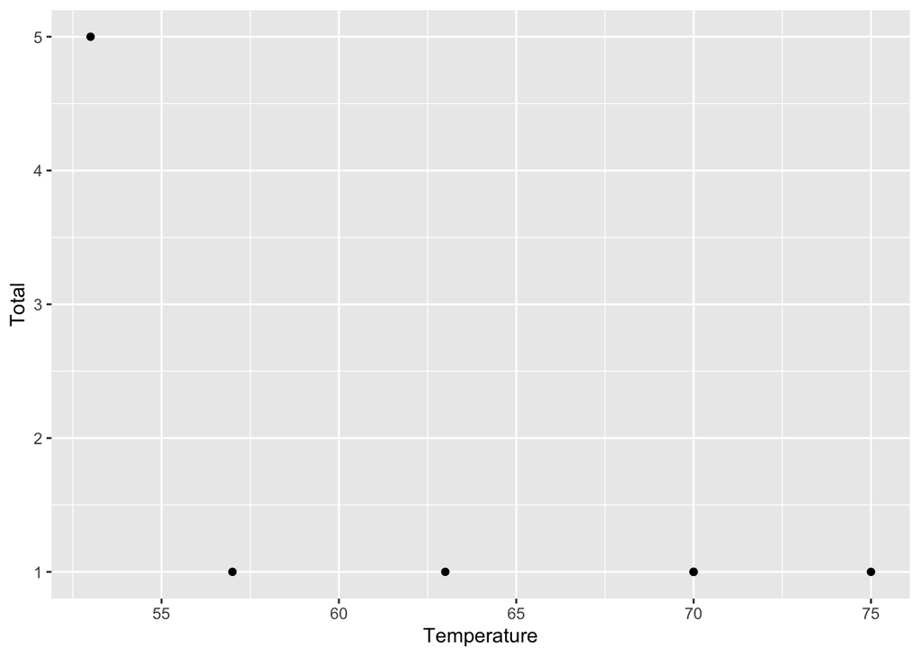

```r
library(DAAG)
library(ggplot2)

pre_included.df<-orings[c(1,2,4,11,13,18),]

ggplot(pre_included.df,aes(x = Temperature,y = Total))+geom_point()+labs(x = "Temperature",y = "Total")
```

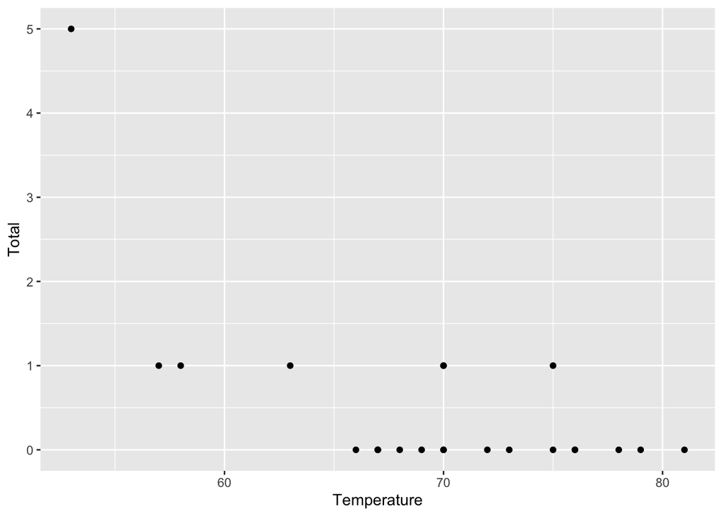

```r
ggplot(orings,aes(x = Temperature,y = Total))+geom_point()+labs(x = "Temperature",y = "Total")
```

## MB.Ch1.4.

```r
library(DAAG)

str(ais)
```

```
## 'data.frame':    202 obs. of  13 variables:
##  $ rcc   : num  3.96 4.41 4.14 4.11 4.45 4.1 4.31 4.42 4.3 4.51 ...
##  $ wcc   : num  7.5 8.3 5 5.3 6.8 4.4 5.3 5.7 8.9 4.4 ...
##  $ hc    : num  37.5 38.2 36.4 37.3 41.5 37.4 39.6 39.9 41.1 41.6 ...
##  $ hg    : num  12.3 12.7 11.6 12.6 14 12.5 12.8 13.2 13.5 12.7 ...
##  $ ferr  : num  60 68 21 69 29 42 73 44 41 44 ...
##  $ bmi   : num  20.6 20.7 21.9 21.9 19 ...
##  $ ssf   : num  109.1 102.8 104.6 126.4 80.3 ...
##  $ pcBfat: num  19.8 21.3 19.9 23.7 17.6 ...
##  $ lbm   : num  63.3 58.5 55.4 57.2 53.2 ...
##  $ ht    : num  196 190 178 185 185 ...
##  $ wt    : num  78.9 74.4 69.1 74.9 64.6 63.7 75.2 62.3 66.5 62.9 ...
##  $ sex   : Factor w/ 2 levels "f","m": 1 1 1 1 1 1 1 1 1 1 ...
##  $ sport : Factor w/ 10 levels "B_Ball","Field",..: 1 1 1 1 1 1 1 1 1 1 ...
```

```r
apply(ais, 2, anyNA)
```

```
##    rcc    wcc     hc     hg   ferr    bmi    ssf pcBfat    lbm     ht     wt
##  FALSE  FALSE  FALSE  FALSE  FALSE  FALSE  FALSE  FALSE  FALSE  FALSE  FALSE
##    sex  sport
##  FALSE  FALSE
```

```r
sex_sport_tb <- table(ais$sex,ais$sport)
sex_sport_tb
```

```
##
##     B_Ball Field Gym Netball Row Swim T_400m T_Sprnt Tennis W_Polo
##   f     13     7   4      23  22    9     11       4      7      0
##   m     12    12   0       0  15   13     18      11      4     17
```

```r
(as.vector(sex_sport_tb[1,])/as.vector(sex_sport_tb[2,])) < (1/3) | (as.vector(sex_sport_tb[1,])/as.vector(sex_sport_tb[2,])) > 3
```

```
##  [1] FALSE FALSE  TRUE  TRUE FALSE FALSE FALSE FALSE FALSE  TRUE
```

## MB.Ch1.6.

```r
Manitoba.lakes <- data.frame("elevation" = c(217,254,248,254,253,227,178,207,217), "area" = c(24387,5374,4624,2247,1353,1223,1151,755,657))
row.names(Manitoba.lakes) <- c("Winnipeg","Winnipegosis","Manitoba","SouthernIndian","Cedar","Island","Gods","Cross","Playgreen")
Manitoba.lakes
```

```
##                elevation  area
## Winnipeg             217 24387
## Winnipegosis         254  5374
## Manitoba             248  4624
## SouthernIndian       254  2247
## Cedar                253  1353
## Island               227  1223
## Gods                 178  1151
## Cross                207   755
## Playgreen            217   657
```

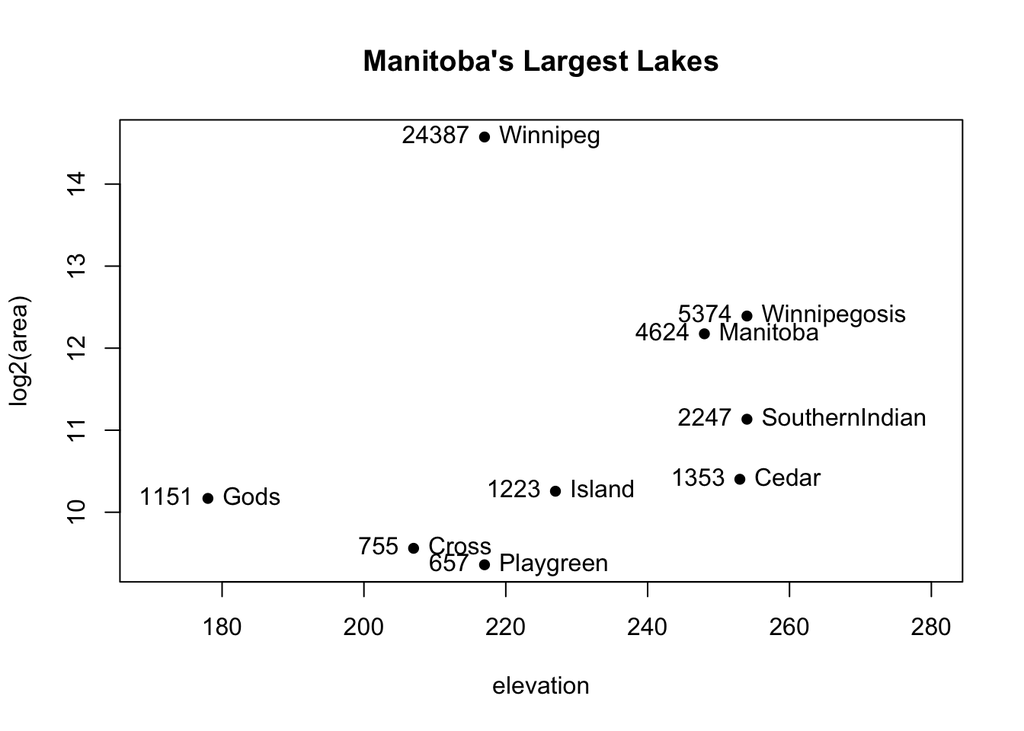

```r
attach(Manitoba.lakes)
plot(log2(area) ~ elevation, pch=16, xlim=c(170,280))
text(log2(area) ~ elevation, labels=row.names(Manitoba.lakes), pos=4)
text(log2(area) ~ elevation, labels=area, pos=2)
title("Manitoba's Largest Lakes")
```

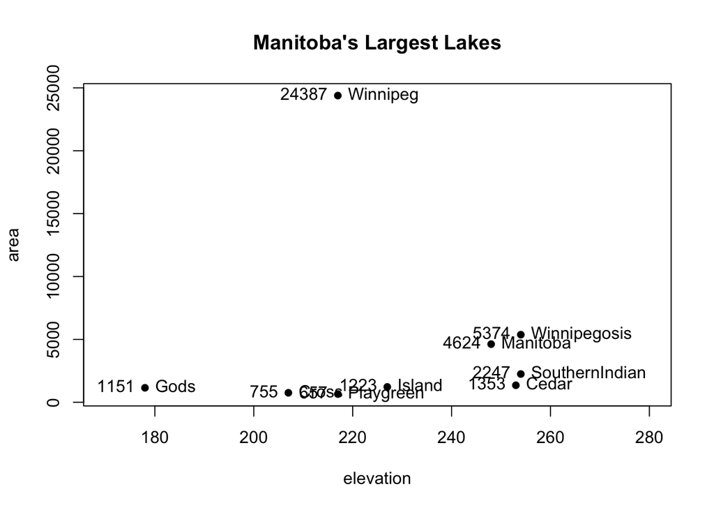

```r
plot(area ~ elevation, pch=16, xlim=c(170,280), ylog=T)
text(area ~ elevation, labels=row.names(Manitoba.lakes), pos=4, ylog=T)
text(area ~ elevation, labels=area, pos=2, ylog=T)
title("Manitoba's Largest Lakes")
```

## MB.Ch1.7.

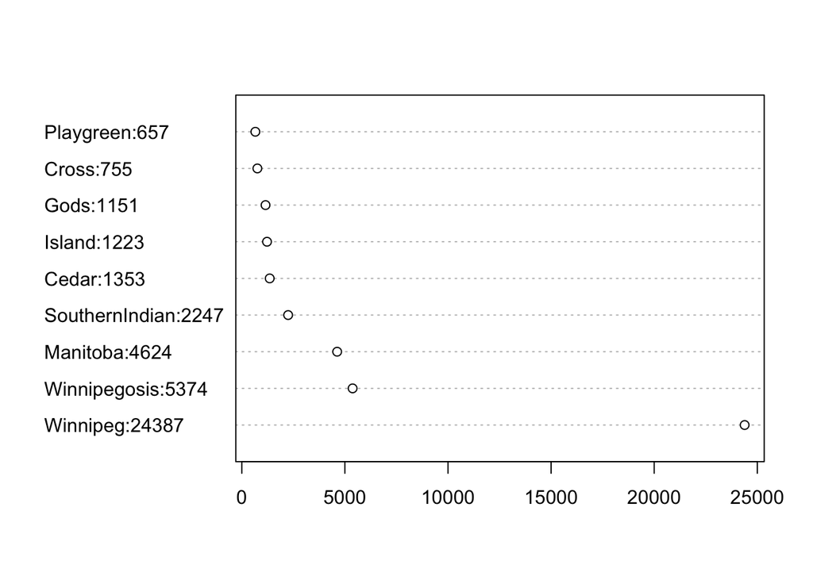

```r
library(DAAG)

combined_labels <- paste(rownames(Manitoba.lakes),Manitoba.lakes$area,sep = ":")
dotchart(Manitoba.lakes$area, labels = combined_labels)
```

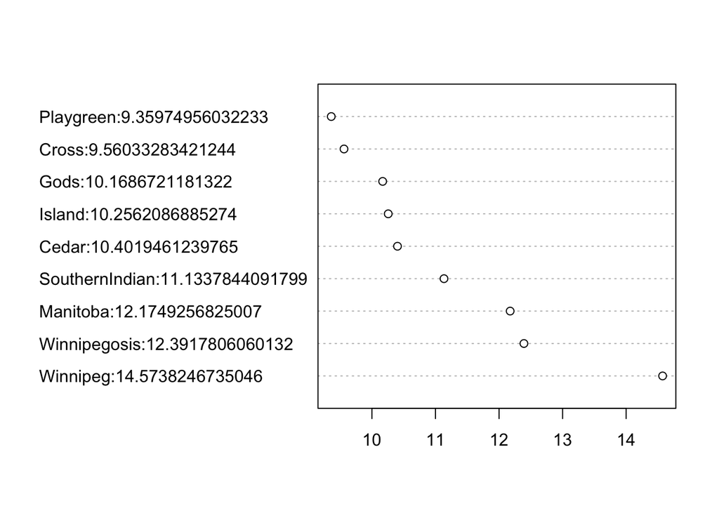

```r
combined_labels_log <- paste(rownames(Manitoba.lakes),log2(Manitoba.lakes$area),sep = ":")
dotchart(log2(Manitoba.lakes$area), labels = combined_labels_log)
```

## MB.Ch1.8.

```r
library(DAAG)

sum(Manitoba.lakes$area)
```

```
## [1] 41771
```